# Multiple Sclerosis and Machine Learning

## 1. Overview

**What is multiple sclerosis?** Explanation and Image from MAYO CLINIC:  
Ref: https://www.mayoclinic.org/diseases-conditions/multiple-sclerosis/symptoms-causes/syc-20350269

Multiple sclerosis (MS) is a potentially disabling disease of the brain and spinal cord (central nervous system).

In MS, the immune system attacks the protective sheath (myelin) that covers nerve fibers and causes communication problems between your brain and the rest of your body. Eventually, the disease can cause permanent damage or deterioration of the nerve fibers.

Signs and symptoms of MS vary widely between patients and depend on the location and severity of nerve fiber damage in the central nevous system. Some people with severe MS may lose the ability to walk independently or ambulate at all. Other individuals may experience long periods of remission without any new symptoms depending on the type of MS they have.

There’s no cure for multiple sclerosis. However, there are treatments to help speed the recovery from attacks, modify the course of the disease and manage symptoms

[figure not shown]

## 2. About Dataset

Prospective cohort study was conducted in Mexican mestizo patients newly diagnosed with CIS who presented at the National Institute of Neurology and Neurosurgery (NINN) in Mexico City, Mexico, between 2006 and 2010.  
**Data source:** https://www.kaggle.com/code/sanjaymandal/multiple-sclerosis/input  
**Dataset column descriptions:**

1. ID: Patient identifier (int)
2. Age: Age of the patient (in years)
3. Schooling: time the patient spent in school (in years)
4. Gender: 1=male, 2=female
5. Breastfeeding: 1=yes, 2=no, 3=unknown
6. Varicella: 1=positive, 2=negative, 3=unknown
7. Initial_Symptoms: 1=visual, 2=sensory, 3=motor, 4=other, 5= visual and sensory, 6=visual and motor, 7=visual and others, 8=sensory and motor, 9=sensory and other, 10=motor and other, 11=Visual, sensory and motor, 12=visual, sensory and other, 13=Visual, motor and other, 14=Sensory, motor and other, 15=visual,sensory,motor and other
8. Mono _or_Polysymptomatic: 1=monosymptomatic, 2=polysymptomatic, 3=unknown
9. Oligoclonal_Bands: 0=negative, 1=positive, 2=unknown
10. LLSSEP: 0=negative, 1=positive
11. ULSSEP:0=negative, 1=positive
12. VEP:0=negative, 1=positive
13. BAEP: 0=negative, 1=positive
14. Periventricular_MRI:0=negative, 1=positive
15. Cortical_MRI: 0=negative, 1=positive
16. Infratentorial_MRI:0=negative, 1=positive
17. Spinal_Cord_MRI: 0=negative, 1=positive
18. initial_EDSS:? (Expanded Disability Status Scale)
19. final_EDSS:?
20. Group: 1=CDMS, 2=non-CDMS (Clinically Definite Multiple Sclerosis)

## 3. Importing Dataset :: Fix Pameters :: Review Dataset :: Descriptive Stats

### 3.1 Import and Fix Pameters

```r
library(tidyverse)
library(kableExtra)
library(dplyr)
mcsvname <-"conversion_predictors_of_clinically_isolated_syndrome_to_multiple_sclerosis.csv"
mydata <- read.csv(paste0("C:/R_Projects/Multiple_Sclerosis/Dataset/",mcsvname),header = TRUE)

# Removing columns that are not required and omiting NAs
mydata        <- subset(mydata, select = -c(1,Initial_EDSS,Final_EDSS))
mydata        <- na.omit(mydata)

# Declaring all variables and Parameters
mdependvar    <- 'group'
mbinaryOne    <- 1
mbinaryTwo    <- 2
mbinaryOneTxt <- 'CDMS'
mbinaryTwoTxt <- 'NON-CDMS'
n=which(colnames(mydata)== mdependvar)

# Declaring formula for model building, you get output like this group~.
f2 <- as.formula(paste(text=mdependvar,"~", "."))
```

### 3.2 Review Dataset

Review your Data

| Gender | Age | Schooling | Breastfeeding | Varicella | Initial Symptom | Mono or Polysymptomatic | Oligoclonal Bands | LLSSEP | ULSSEP | VEP | BAEP | Periventricular MRI | Cortical MRI | Infratentorial MRI | Spinal Cord MRI | group |
| --- | --- | --- | --- | --- | --- | --- | --- | --- | --- | --- | --- | --- | --- | --- | --- | --- |
| 1 | 34 | 20 | 1 | 1 | 2 | 1 | 0 | 1 | 1 | 0 | 0 | 0 | 1 | 0 | 1 | 1 |
| 1 | 61 | 25 | 3 | 2 | 10 | 2 | 1 | 1 | 0 | 1 | 0 | 0 | 0 | 0 | 1 | 1 |
| 1 | 22 | 20 | 3 | 1 | 3 | 1 | 1 | 0 | 0 | 0 | 0 | 0 | 1 | 0 | 0 | 1 |
| 2 | 41 | 15 | 1 | 1 | 7 | 2 | 1 | 0 | 1 | 1 | 0 | 1 | 1 | 0 | 0 | 1 |
| 2 | 34 | 20 | 2 | 1 | 6 | 2 | 0 | 1 | 0 | 0 | 0 | 1 | 0 | 0 | 0 | 1 |
| 1 | 29 | 22 | 1 | 1 | 6 | 2 | 0 | 1 | 0 | 0 | 0 | 1 | 0 | 1 | 0 | 1 |
| 2 | 53 | 20 | 1 | 1 | 14 | 2 | 0 | 1 | 0 | 1 | 0 | 1 | 1 | 0 | 1 | 1 |
| 2 | 24 | 15 | 1 | 1 | 14 | 2 | 0 | 1 | 1 | 0 | 0 | 1 | 1 | 1 | 1 | 1 |
| 1 | 36 | 15 | 1 | 1 | 8 | 2 | 0 | 1 | 1 | 1 | 0 | 1 | 0 | 0 | 0 | 1 |
| 2 | 28 | 20 | 1 | 1 | 8 | 2 | 0 | 0 | 0 | 0 | 0 | 1 | 0 | 1 | 0 | 1 |

### 3.3. Descriptive Statistics

| variables | mean_sd | CI | Variance | range | min | max | IQR | median | coff_var |
| --- | --- | --- | --- | --- | --- | --- | --- | --- | --- |
| Gender | 1.61 ± 0.49 | 1.55-1.67 | 0.24 | 1 | 1 | 2 | 1 | 2 | 0.3 |
| Age | 34.11 ± 11.11 | 32.78-35.44 | 123.43 | 62 | 15 | 77 | 14.5 | 33 | 0.33 |
| Schooling | 15.19 ± 4.25 | 14.68-15.7 | 18.04 | 25 | 0 | 25 | 8 | 15 | 0.28 |
| Breastfeeding | 1.82 ± 0.87 | 1.72-1.93 | 0.76 | 2 | 1 | 3 | 2 | 2 | 0.48 |
| Varicella | 1.70 ± 0.73 | 1.61-1.79 | 0.53 | 2 | 1 | 3 | 1 | 2 | 0.43 |
| Initial_Symptom | 6.45 ± 4.22 | 5.94-6.95 | 17.82 | 14 | 1 | 15 | 6 | 6 | 0.65 |
| Mono_or_Polysymptomatic | 1.72 ± 0.49 | 1.66-1.78 | 0.24 | 2 | 1 | 3 | 1 | 2 | 0.28 |
| Oligoclonal_Bands | 0.35 ± 0.55 | 0.28-0.42 | 0.3 | 2 | 0 | 2 | 1 | 0 | 1.57 |
| LLSSEP | 0.42 ± 0.50 | 0.37-0.48 | 0.25 | 1 | 0 | 1 | 1 | 0 | 1.17 |
| ULSSEP | 0.37 ± 0.48 | 0.31-0.43 | 0.23 | 1 | 0 | 1 | 1 | 0 | 1.31 |

[output cut: 7 more lines]

## 4. Analyze the Correlation between variables

### 4.1. Correlation Plot

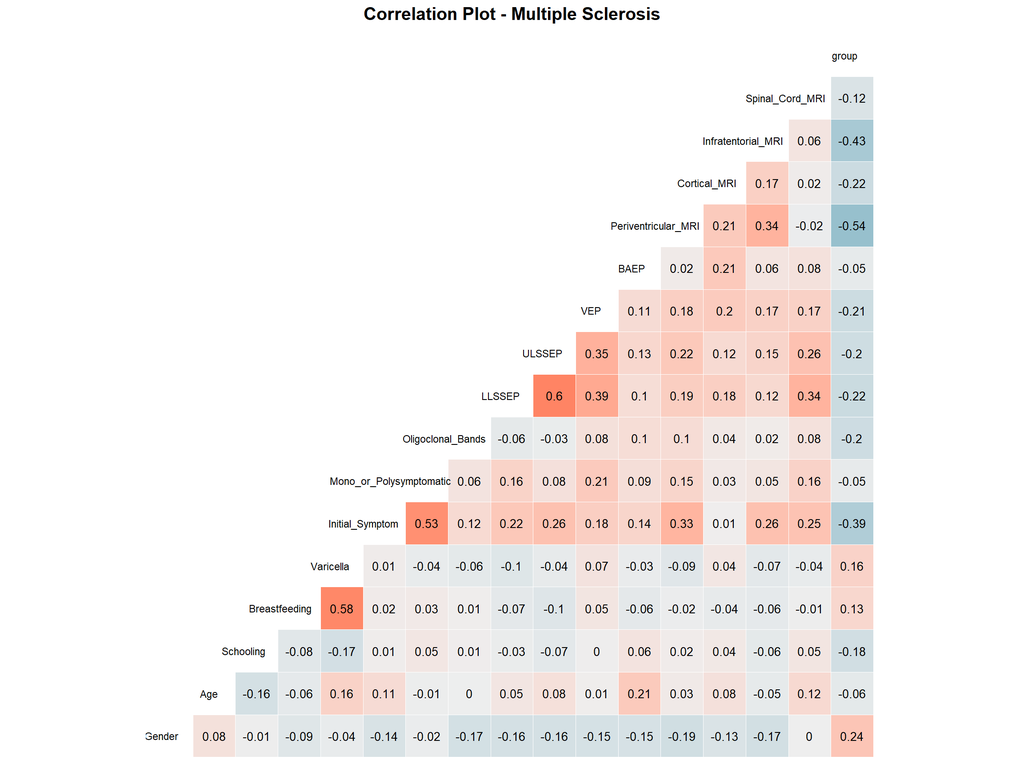

### 4.2. Correlation matrix

Review of Correlation

|  | Gender | Age | Schooling | Breastfeeding | Varicella | Initial Symptom | Mono or Polysymptomatic | Oligoclonal Bands | LLSSEP | ULSSEP | VEP | BAEP | Periventricular MRI | Cortical MRI | Infratentorial MRI | Spinal Cord MRI | group | Column_Name |
| --- | --- | --- | --- | --- | --- | --- | --- | --- | --- | --- | --- | --- | --- | --- | --- | --- | --- | --- |
| Gender | 1 | 0.08 | -0.01 | -0.09 | -0.04 | -0.14 | -0.02 | -0.17 | -0.16 | -0.16 | -0.15 | -0.15 | -0.19 | -0.13 | -0.17 | 0 | 0.24 | Gender |
| Age | 0.08 | 1 | -0.16 | -0.06 | 0.16 | 0.11 | -0.01 | 0 | 0.05 | 0.08 | 0.01 | 0.21 | 0.03 | 0.08 | -0.05 | 0.12 | -0.06 | Age |
| Schooling | -0.01 | -0.16 | 1 | -0.08 | -0.17 | 0.01 | 0.05 | 0.01 | -0.03 | -0.07 | 0 | 0.06 | 0.02 | 0.04 | -0.06 | 0.05 | -0.18 | Schooling |
| Breastfeeding | -0.09 | -0.06 | -0.08 | 1 | 0.58 | 0.02 | 0.03 | 0.01 | -0.07 | -0.1 | 0.05 | -0.06 | -0.02 | -0.04 | -0.06 | -0.01 | 0.13 | Breastfeeding |
| Varicella | -0.04 | 0.16 | -0.17 | 0.58 | 1 | 0.01 | -0.04 | -0.06 | -0.1 | -0.04 | 0.07 | -0.03 | -0.09 | 0.04 | -0.07 | -0.04 | 0.16 | Varicella |
| Initial Symptom | -0.14 | 0.11 | 0.01 | 0.02 | 0.01 | 1 | 0.53 | 0.12 | 0.22 | 0.26 | 0.18 | 0.14 | 0.33 | 0.01 | 0.26 | 0.25 | -0.39 | Initial Symptom |
| Mono or Polysymptomatic | -0.02 | -0.01 | 0.05 | 0.03 | -0.04 | 0.53 | 1 | 0.06 | 0.16 | 0.08 | 0.21 | 0.09 | 0.15 | 0.03 | 0.05 | 0.16 | -0.05 | Mono or Polysymptomatic |
| Oligoclonal Bands | -0.17 | 0 | 0.01 | 0.01 | -0.06 | 0.12 | 0.06 | 1 | -0.06 | -0.03 | 0.08 | 0.1 | 0.1 | 0.04 | 0.02 | 0.08 | -0.2 | Oligoclonal Bands |
| LLSSEP | -0.16 | 0.05 | -0.03 | -0.07 | -0.1 | 0.22 | 0.16 | -0.06 | 1 | 0.6 | 0.39 | 0.1 | 0.19 | 0.18 | 0.12 | 0.34 | -0.22 | LLSSEP |
| ULSSEP | -0.16 | 0.08 | -0.07 | -0.1 | -0.04 | 0.26 | 0.08 | -0.03 | 0.6 | 1 | 0.35 | 0.13 | 0.22 | 0.12 | 0.15 | 0.26 | -0.2 | ULSSEP |
| VEP | -0.15 | 0.01 | 0 | 0.05 | 0.07 | 0.18 | 0.21 | 0.08 | 0.39 | 0.35 | 1 | 0.11 | 0.18 | 0.2 | 0.17 | 0.17 | -0.21 | VEP |
| BAEP | -0.15 | 0.21 | 0.06 | -0.06 | -0.03 | 0.14 | 0.09 | 0.1 | 0.1 | 0.13 | 0.11 | 1 | 0.02 | 0.21 | 0.06 | 0.08 | -0.05 | BAEP |
| Periventricular MRI | -0.19 | 0.03 | 0.02 | -0.02 | -0.09 | 0.33 | 0.15 | 0.1 | 0.19 | 0.22 | 0.18 | 0.02 | 1 | 0.21 | 0.34 | -0.02 | -0.54 | Periventricular MRI |
| Cortical MRI | -0.13 | 0.08 | 0.04 | -0.04 | 0.04 | 0.01 | 0.03 | 0.04 | 0.18 | 0.12 | 0.2 | 0.21 | 0.21 | 1 | 0.17 | 0.02 | -0.22 | Cortical MRI |
| Infratentorial MRI | -0.17 | -0.05 | -0.06 | -0.06 | -0.07 | 0.26 | 0.05 | 0.02 | 0.12 | 0.15 | 0.17 | 0.06 | 0.34 | 0.17 | 1 | 0.06 | -0.43 | Infratentorial MRI |
| Spinal Cord MRI | 0 | 0.12 | 0.05 | -0.01 | -0.04 | 0.25 | 0.16 | 0.08 | 0.34 | 0.26 | 0.17 | 0.08 | -0.02 | 0.02 | 0.06 | 1 | -0.12 | Spinal Cord MRI |
| group | 0.24 | -0.06 | -0.18 | 0.13 | 0.16 | -0.39 | -0.05 | -0.2 | -0.22 | -0.2 | -0.21 | -0.05 | -0.54 | -0.22 | -0.43 | -0.12 | 1 | group |

## 5. Split Dataset as Train and Test

```r
# converting dependent variable as factor
mydata[,n] <- as.factor(mydata[,n])

# Split Dataset as Train and Test
set.seed(123)
indms <- sample(2, nrow(mydata), replace = TRUE, prob = c(0.7,0.3))
trainData <- mydata[ indms == 1,]
testData <- mydata [indms ==2,]
```

## 6. Developing 14 Classification Models

### 6.1. Decision Tree C5.0

```r
library(C50)
library(caret)
model_c50 <- C5.0(trainData[,-n],trainData[,n])
pred_c50 <- predict(model_c50, testData[,-n])
cmx_c50 <- confusionMatrix(pred_c50, testData[,n])
```

### 6.2. Decision Tree Tune C5.0

```r
library(C50)
library(caret)
acc_test <- numeric()
accuracy1 <- NULL; accuracy2 <- NULL

for(i in 1:50){
  model_imp_c50 <- C5.0(trainData[,-n],trainData[,n],trials = i)
  p_c50 <- predict(model_imp_c50, testData[,-n])
  accuracy1 <- confusionMatrix(p_c50, testData[,n])
  accuracy2[i] <- accuracy1$overall[1]
}
acc <- data.frame(t= seq(1,50), cnt = accuracy2)
opt_t <- subset(acc, cnt==max(cnt))[1,]

model_imp_c50 <- C5.0(trainData[,-n],trainData[,n],trials=opt_t$t)
pred_imp_c50 <- predict(model_imp_c50, testData[,-n])
cmx_imp_c50 <- confusionMatrix(pred_imp_c50, testData[,n])
```

### 6.3. Recursive Partitioning (RPART)

```r
library(rpart)
library(caret)
model_rp <- rpart(f2,data=trainData,control=rpart.control(minsplit=2),method = 'class')
pred_rp <- predict(model_rp, testData[,-n], type="class")
cmx_rp  <- confusionMatrix(pred_rp, testData[,n])
```

### 6.4. Prune Recursive Partitioning (PRUNE RPART)

```r
library(rpart)
library(caret)
model_pru <- prune(model_rp, cp=model_rp$cptable[which.min(model_rp$cptable[,"xerror"]),"CP"])
pred_pru <- predict(model_pru, testData[,-n], type="class")
cmx_pru <-confusionMatrix(pred_pru, testData[,n])
```

### 6.5. Random Forest

```r
library(randomForest)
library(caret)
model_rf <- randomForest(f2, data=trainData, ntree=300, proximity=T, importance=T,
                             na.action = na.omit)
pred_rf   <- predict(model_rf, testData[,-n])
cmx_rf    <- confusionMatrix(pred_rf, testData[,n])
```

### 6.6. Support Vector Machine (SVM)

```r
library(e1071)
library(caret)
model_svm <- svm(f2, data=trainData)
pred_svm <- predict(model_svm, testData[,-n])
cmx_svm <- confusionMatrix(pred_svm, testData[,n])
```

### 6.7. Tune Support Vector Machine (TUNE SVM)

```r
library(e1071)
library(caret)
gamma <- seq(0,0.1,0.005)
cost <- 2^(0:5)
parms <- expand.grid(cost=cost, gamma=gamma)    ## 231

acc_test <- numeric()
accuracy1 <- NULL; accuracy2 <- NULL

for(i in 1:NROW(parms)){
  model_svm <- svm(f2, data=trainData, gamma=parms$gamma[i], cost=parms$cost[i])
  pred_svm <- predict(model_svm, testData[,-n])
  accuracy1 <- confusionMatrix(pred_svm, testData[,n])
  accuracy2[i] <- accuracy1$overall[1]
}
acc <- data.frame(p= seq(1,NROW(parms)), cnt = accuracy2)
opt_p <- subset(acc, cnt==max(cnt))[1,]

model_imp_svm <- svm(f2, data=trainData, cost=parms$cost[opt_p$p], gamma=parms$gamma[opt_p$p])
pred_imp_svm <- predict(model_imp_svm, testData[,-n])
cmx_imp_svm <- confusionMatrix(pred_imp_svm, testData[,n])
```

### 6.8. Logistic Regression

```r
library(caret)
xxx <- paste0("trainData$",mdependvar)
f2A <- as.formula(paste(text=xxx,"~", "."))
model_lreg<-glm(f2A,family = binomial(link = 'logit'), data=trainData)

pred1 <- predict(model_lreg, newdata = testData[,-n], type = "response")
y_pred1 <- as.numeric(ifelse( pred1  >= 0.5, 2, 1))
y_pred1  <- factor( y_pred1 , levels = c(1, 2))
y_act1 <- testData[,n]
y_act1  <- factor( y_act1 , levels = c(1, 2))
cmx_lreg<- caret::confusionMatrix(y_pred1, y_act1)
```

### 6.9. Gradient Boosting Machine (GBM)

```r
library(gbm)
library(caret)
test_gbm <- gbm(f2, data=trainData, distribution="gaussian",n.trees = 10000,
                shrinkage = 0.01, interaction.depth = 4, bag.fraction=0.5,train.fraction=0.5,
                n.minobsinnode=10,cv.folds=3,keep.data=TRUE,verbose=FALSE,n.cores=1)
best.iter <- gbm.perf(test_gbm, method="cv",plot.it=FALSE)
fitControl = trainControl(method="cv", number=5, returnResamp="all")

model_gbm = train(f2, data=trainData, method="gbm", distribution="bernoulli", trControl=fitControl,
                  verbose=F, tuneGrid=data.frame(.n.trees=best.iter, .shrinkage=0.01,
                                                 .interaction.depth=1, .n.minobsinnode=1))
pred_gbm <- predict(model_gbm, testData[,-n])
cmx_gbm <- confusionMatrix(pred_gbm, testData[,n])
```

### 6.10. Adaptive Boost (ADABOOST)

```r
library(ada)
library(rpart)
library(caret)
control <- rpart.control(cp = -1, maxdepth = 14,maxcompete = 1,xval = 0)
model_ada <- ada(f2, data = trainData, test.x = trainData[,-n], test.y = trainData[,n],
                 type = "gentle", control = control, iter = 70)
pred_ada <- predict(model_ada, testData[,-n])
cmx_ada <- confusionMatrix(pred_ada, testData[,n])
```

### 6.11. Naive Bayes Classifier

```r
library(e1071)
library(caret)

acc_test <- numeric()
accuracy1 <- NULL; accuracy2 <- NULL

for(i in 1:30){
  model_imp_nb <- naiveBayes(trainData[,-n], trainData[,n], laplace=i)
  p_nb <- predict(model_imp_nb, testData[,-n])
  accuracy1 <- confusionMatrix(p_nb, testData[,n])
  accuracy2[i] <- accuracy1$overall[1]
}

acc <- data.frame(l= seq(1,30), cnt = accuracy2)

opt_l <- subset(acc, cnt==max(cnt))[1,]
model_nb <- naiveBayes(trainData[,-n], trainData[,n])
pred_nb <- predict(model_nb, testData[,-n])
cmx_nb <- confusionMatrix(pred_nb, testData[,n])
```

### 6.12. K-Nearest Neighbors (KNN)

```r
library(caret)

ctrl <- trainControl(method = "cv", verboseIter = FALSE, number = 5)
model_knn <- train(f2,data = trainData, method = "knn", preProcess = c("center","scale"),
                    trControl = ctrl , tuneGrid = expand.grid(k = seq(1, 20, 2)))
predictions <- predict(model_knn,newdata = testData[,-n] )
cmx_knn <- confusionMatrix(predictions, testData[,n] )
```

### 6.13. Linear Discriminant Analysis (LDA)

```r
library(caret)
model_lda <- train(f2, method = "lda", data = trainData)
pred_lda <- predict(model_lda, testData[,-n])
cmx_lda <- confusionMatrix(pred_lda, testData[,n])
```

### 6.14. Quadrant Discriminant Analysis (QDA)

```r
library(caret)
model_qda <- train(f2, method = "qda", data = trainData)
pred_qda <- predict(model_qda , testData[,-n])
cmx_qda <- confusionMatrix(pred_qda, testData[,n])
```

## 7. Confusion Matrix Custom Function

Thanks to Cybernetic and Breck, Data Scientist at UH Cancer Center for the valuable contribution at stackoverflow.com on R how to visualize confusion matrix using the caret package. I made marginal improvement by adding totals all round matrix and column names and modified reported statistics. Link to stackoverflow.com: https://stackoverflow.com/questions/23891140/r-how-to-visualize-confusion-matrix-using-the-caret-package/42940553#42940553

```r
fnpercent <- function(x, digits = 2, format = "f", ...) {      # Create user-defined function
  paste0(formatC(x * 100, format = format, digits = digits, ...), "%")
}

fnConfusionMatrix <- function(xresults1,xmbinaryOneTxt=mbinaryOneTxt,xmbinaryTwoTxt=mbinaryTwoTxt,xtitle='Confusion Matrix'){
    rownames(xresults1$table)<-ifelse(rownames(xresults1$table)=="1",xmbinaryOneTxt,xmbinaryTwoTxt)
    colnames(xresults1$table)<-ifelse(colnames(xresults1$table)=="1",xmbinaryOneTxt,xmbinaryTwoTxt)

    total <- sum(xresults1$table)
    res <- as.numeric(xresults1$table)

    # Generate color gradients. Palettes come from RColorBrewer.
    greenPalette <- c("#F7FCF5","#E5F5E0","#C7E9C0","#A1D99B","#74C476","#41AB5D","#238B45","#006D2C","#00441B")
    redPalette <- c("#FFF5F0","#FEE0D2","#FCBBA1","#FC9272","#FB6A4A","#EF3B2C","#CB181D","#A50F15","#67000D")
    getColor <- function (greenOrRed = "green", amount = 0) {
      if (amount == 0)
        return("#FFFFFF")
      palette <- greenPalette
      if (greenOrRed == "red")
        palette <- redPalette
      colorRampPalette(palette)(100)[10 + ceiling(90 * amount / total)]
    }

    # set the basic layout
    layout(matrix(c(1,1,2)))
    par(mar=c(2,2,2,2))
    plot(c(125, 355), c(270, 450), type = "n", xlab="", ylab="", xaxt='n', yaxt='n')
    title(xtitle, cex.main=2.5,col.main='red')
    # create the matrix
    classes = colnames(xresults1$table)
    rect(150, 430, 240, 370, col=getColor("green", res[1]))
    text(195, 445, classes[1], cex=1.5)
    rect(250, 430, 340, 370, col=getColor("red", res[3]))
    text(295, 445, classes[2], cex=1.5)
    text(130, 370, 'Predicted', cex=1.7, srt=90, font=2)
    text(245, 445, 'Actual', cex=1.7, font=2)
    rect(150, 305, 240, 365, col=getColor("red", res[2]))
    rect(250, 305, 340, 365, col=getColor("green", res[4]))
    text(140, 400, classes[1], cex=1.5, srt=90)
    text(140, 335, classes[2], cex=1.5, srt=90)

    # add in the xresults1 results
    text(195, 400, res[1], cex=2.0, font=2.3, col='black')
    text(195, 335, res[2], cex=2.0, font=2.3, col='black')
    text(295, 400, res[3], cex=2.0, font=2.3, col='black')
    text(295, 335, res[4], cex=2.0, font=2.3, col='black')

    text(195, 285, (res[1]+res[2]), cex=2.0, font=2.3, col='black')
    text(295, 285, (res[3]+res[4]), cex=2.0, font=2.3, col='black')
    text(350, 400, (res[1]+res[3]), cex=2.0, font=2.3, col='black', srt = 90)
    text(350, 335, (res[2]+res[4]), cex=2.0, font=2.3, col='black', srt = 90)
    text(350, 285, (res[1]+res[2]+res[3]+res[4]), cex=2.0, font=2.3, col='black', srt = 90)

    # add in the specifics
    plot(c(100, 0), c(100, 0), type = "n", xlab="", ylab="", main = "Stats", xaxt='n', yaxt='n',cex.main=2.0)
    text(10, 85, names(xresults1$byClass[1]), cex=1.4, font=2)
    text(10, 67, fnpercent(as.numeric(xresults1$byClass[1]), 1), cex=1.6)
    text(32, 85, names(xresults1$byClass[2]), cex=1.4, font=2)
    text(32, 67, fnpercent(as.numeric(xresults1$byClass[2]), 1), cex=1.6)
    text(52, 85, names(xresults1$byClass[5]), cex=1.4, font=2)
    text(52, 67, fnpercent(as.numeric(xresults1$byClass[5]), 1), cex=1.6)
    text(72, 85, "NPV",cex=1.4, font=2)
    text(72, 67, fnpercent(as.numeric(xresults1$byClass[4]), 1), cex=1.6)
    text(92, 85, names(xresults1$byClass[7]), cex=1.4, font=2)
    text(92, 67, fnpercent(as.numeric(xresults1$byClass[7]), 1), cex=1.6)
    # add in the accuracy information
    text(15, 35, names(xresults1$overall[1]),cex=1.4, font=2)
    text(15, 17, fnpercent(as.numeric(xresults1$overall[1]), 1), cex=1.6)
    text(85, 35, names(xresults1$overall[2]), cex=1.4, font=2)
    text(50, 35, "Miss-Classification",cex=1.4, font=2)
    text(50, 17, fnpercent(1-as.numeric(xresults1$overall[1]), 1), cex=1.6)
    text(85, 17, fnpercent(as.numeric(xresults1$overall[2]), 1), cex=1.6)

  }
```

### 7.1. Confusion Matrix - with Statistics

```r
# Let's build a dataframe called objectdf with all required information for confusion matrix
myobject<- c("cmx_c50", "cmx_imp_c50", "cmx_rp", "cmx_pru", "cmx_rf", "cmx_svm",
             "cmx_imp_svm", "cmx_lreg", "cmx_gbm", "cmx_ada", "cmx_nb",
             "cmx_knn", "cmx_lda", "cmx_qda")

mytitle <- c("Decision Tree C5.0", "Decision Tree Tune C5.0", "Recursive Partitioning",
             "Prune Recursive Partitioning", "Random Forest", "SVM", "Tune SVM",
             "Logistic Regression", "GBM", "AdaBoost", "NaiveBayes",
             "K-Nearest Neighbors (KNN", "Linear Discriminant Analysis",
             "Quadrant Discriminant Analysis"
)
myshorttitle <- c("C5.0", "Tune C5.0", "RPart", "Prune RPart", "Random Forest",
                  "SVM", "Tune SVM", "Logistic Regression", "GBM", "AdaBoost",
                  "NaiveBayes", "KNN", "LDA", "QDA"
)

objectdf <- data.frame(myobject,mytitle,myshorttitle)
```

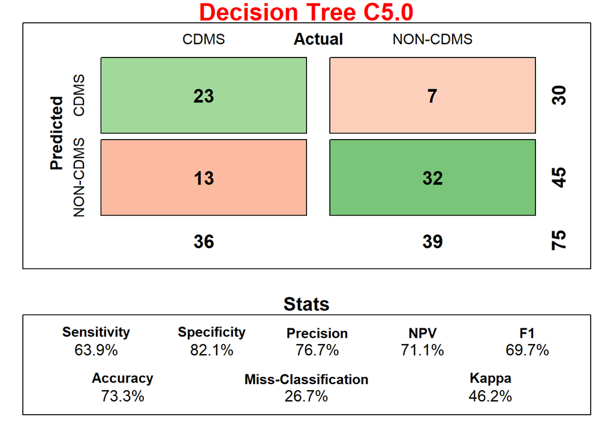

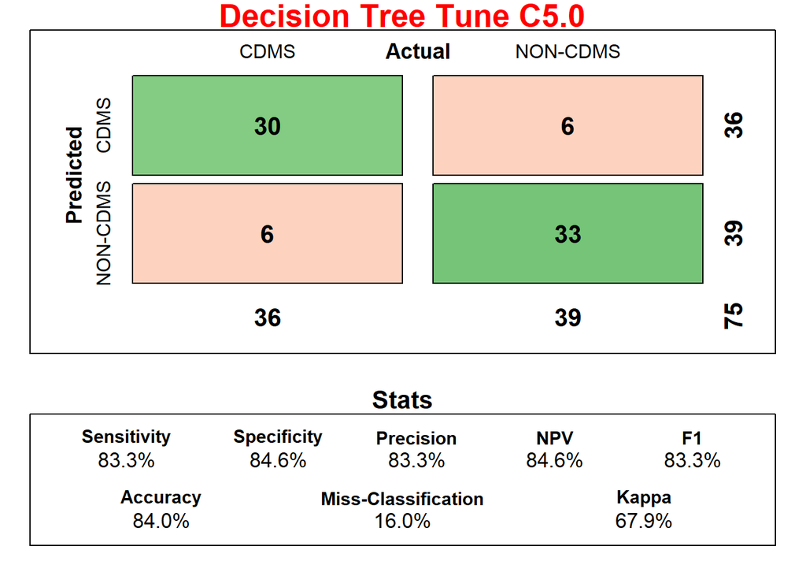

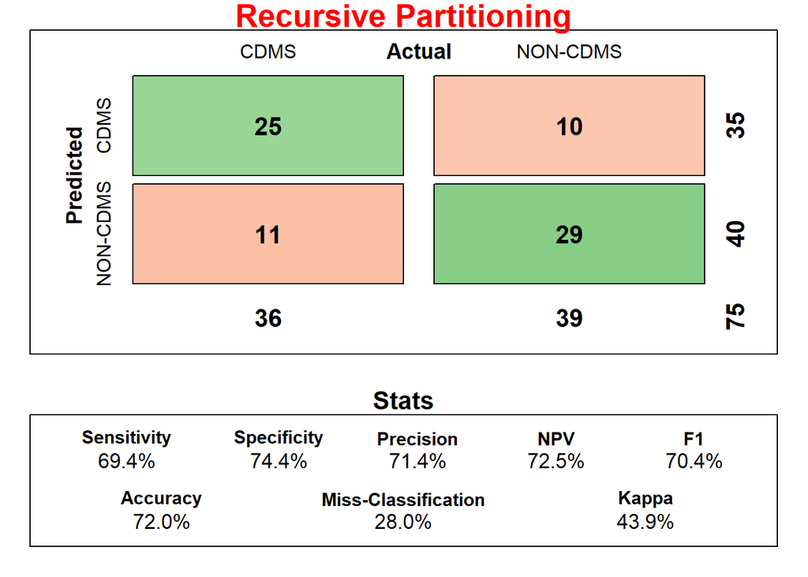

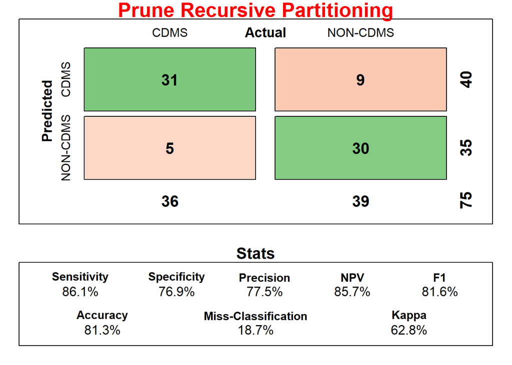

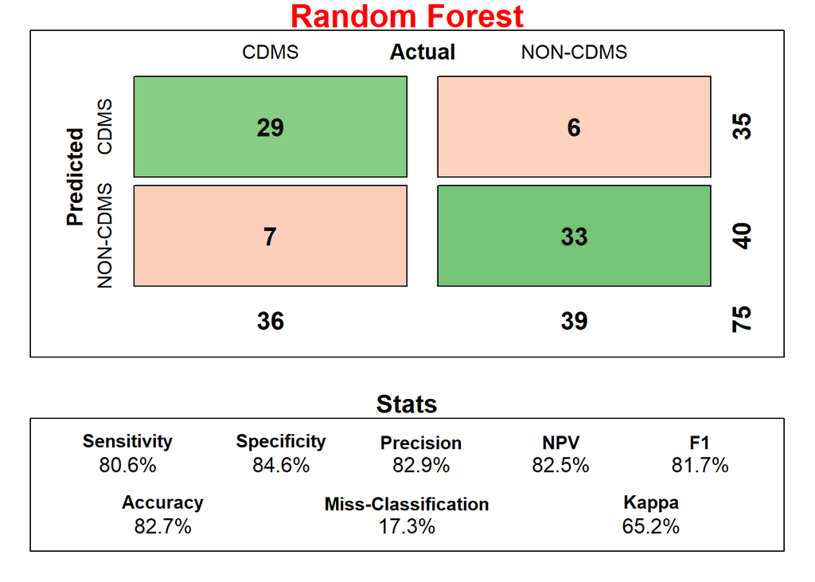

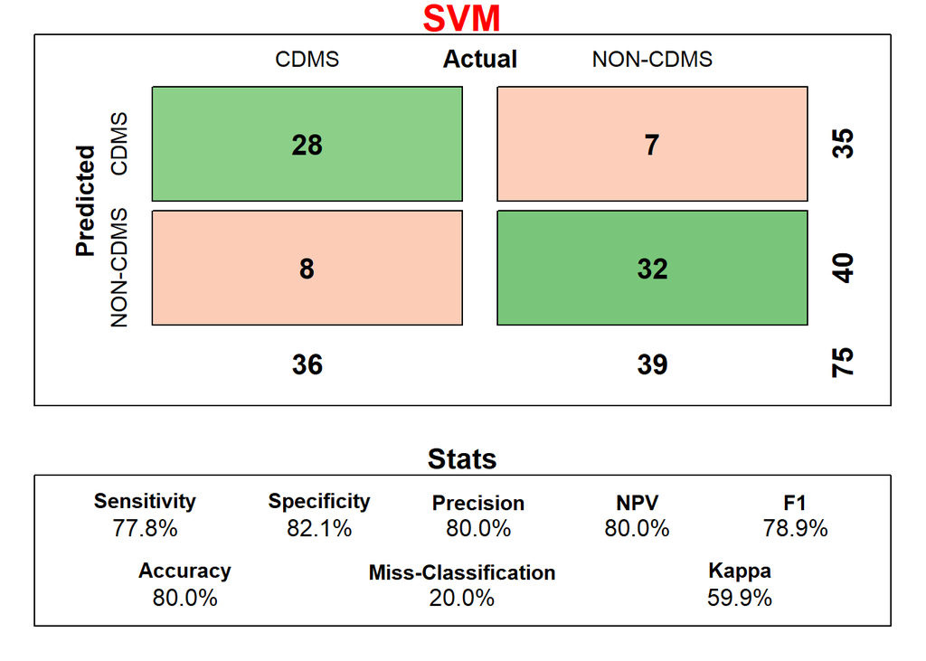

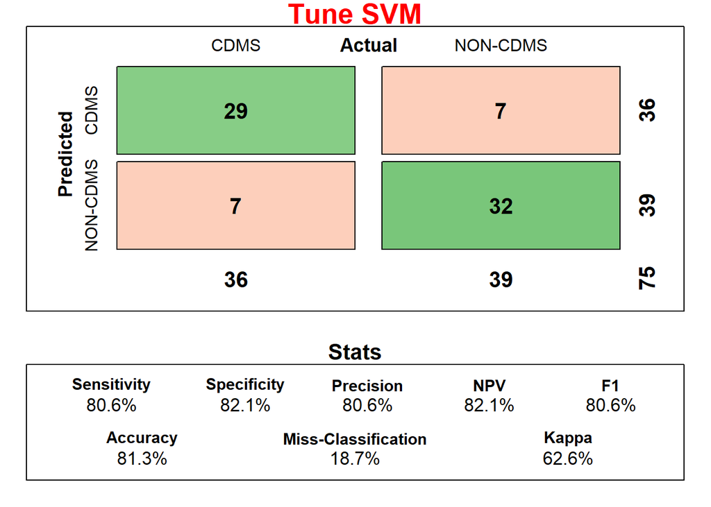

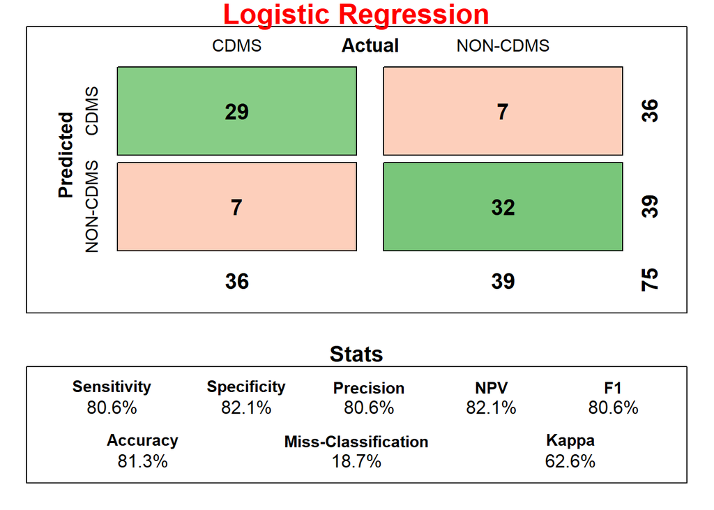

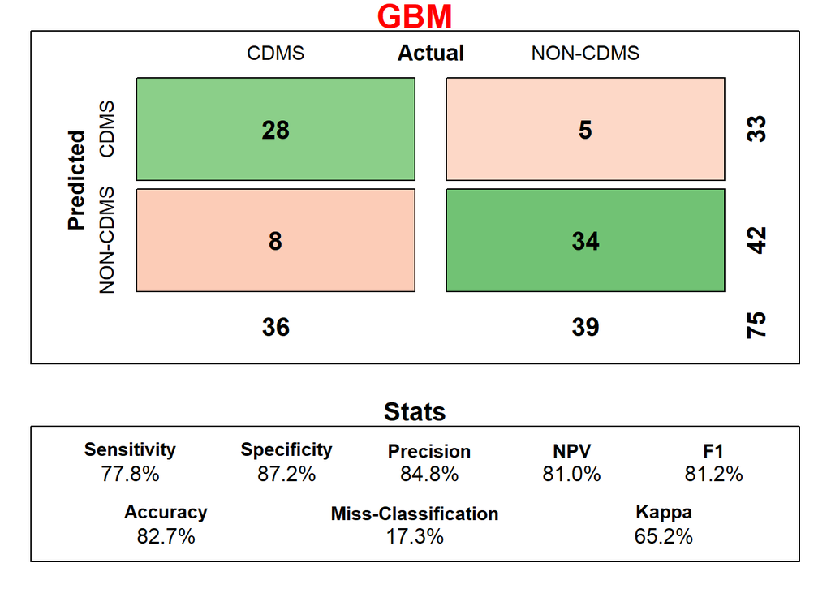

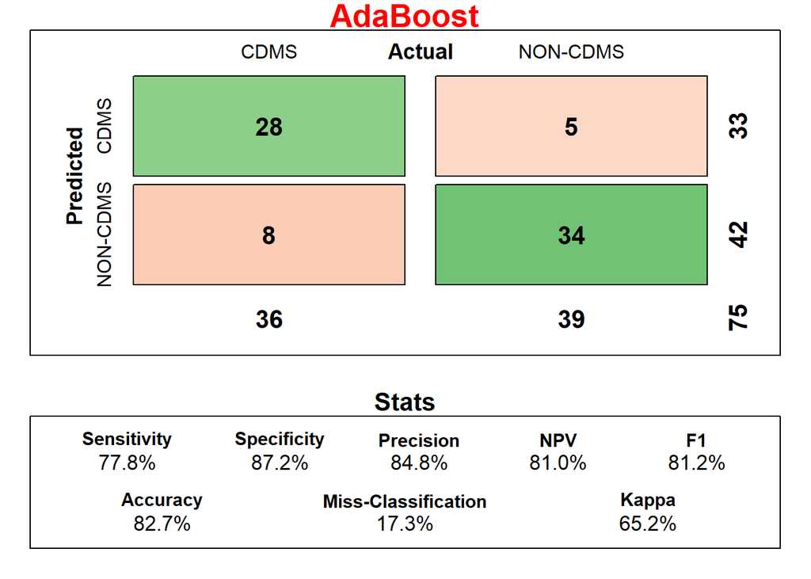

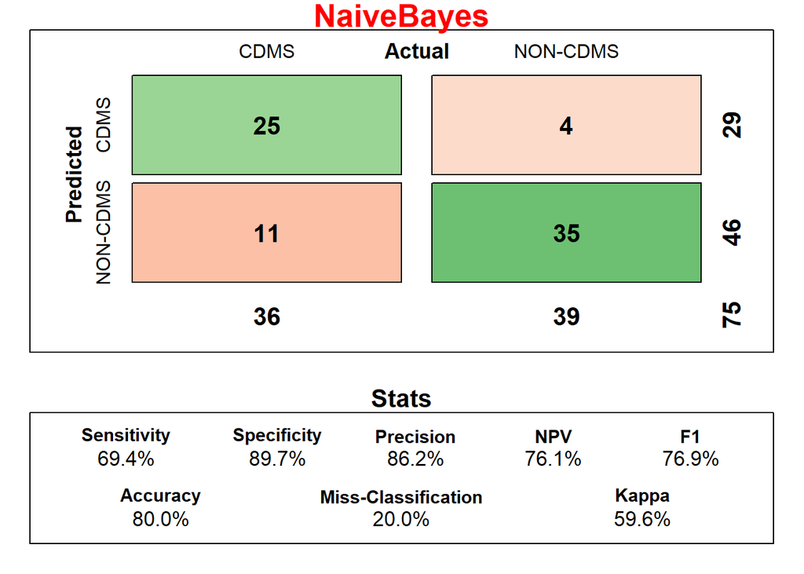

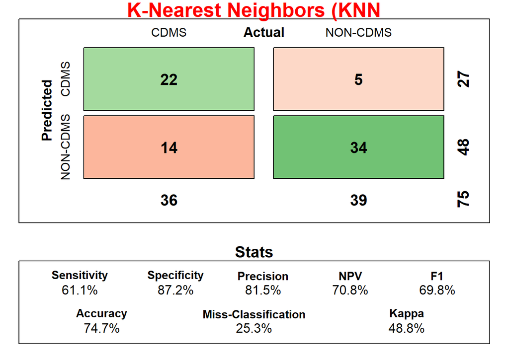

[2 more figures not shown]

### 7.2. Confusion Matrix - Fourfold Plot

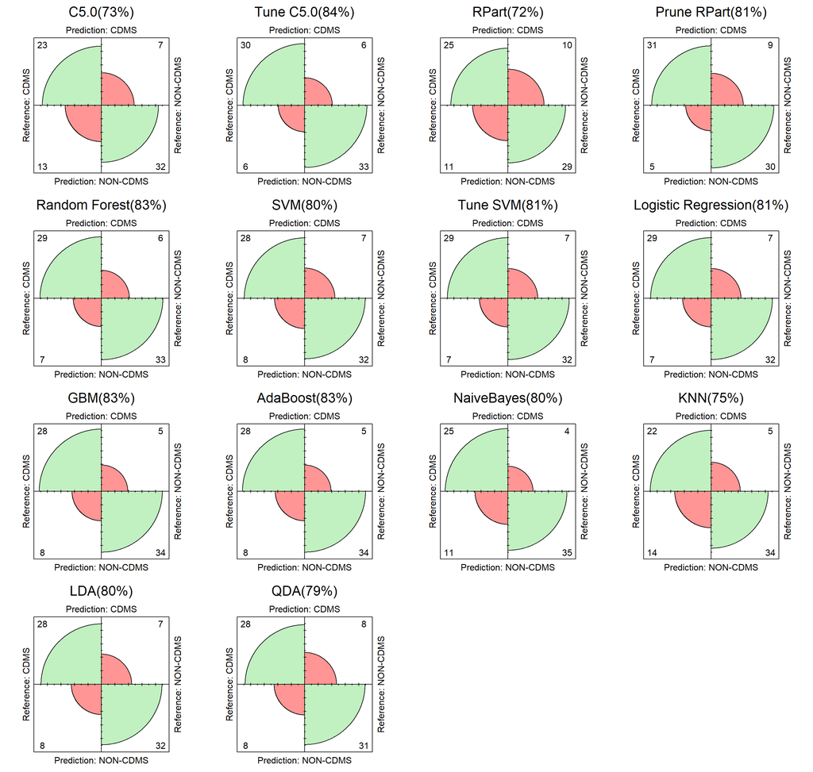

```r
fnfourfoldplot <-function(xresults1,xmbinaryOneTxt=mbinaryOneTxt,xmbinaryTwoTxt=mbinaryTwoTxt,xtitle='Confusion Matrix'){
    rownames(xresults1$table)<-ifelse(rownames(xresults1$table)=="1",xmbinaryOneTxt,xmbinaryTwoTxt)
    colnames(xresults1$table)<-ifelse(colnames(xresults1$table)=="1",xmbinaryOneTxt,xmbinaryTwoTxt)
  fourfoldplot(xresults1$table, color = col, conf.level = 0, margin = 1, main = paste(xtitle,"(",round(xresults1$overall[1]*100),"%)",sep=""))
}

 par(mfrow=c(4,4))
col <- c("#ff9594", "#c1f0c1")

for (i in (1:length(myobject))){
  fnfourfoldplot(xresults1 = get(objectdf$myobject[i]),xtitle=objectdf$myshorttitle[i])
}
```

## 8. Model Prediction

Now let’s take one row from test dataset as new data and try to predict target variable using all 14 algorithms and place it in a dataframe.

### 8.1. New Data Declaration and Predictive Analysis

```r
#New Data Declaration
mrownumber <- 42
mnewdata <- testData[mrownumber,-n]
mtargetvaluenewdata <- ifelse(as.numeric(testData[mrownumber,n]) ==1,mbinaryOneTxt,mbinaryTwoTxt)

model_name <- c("Decision Tree C5.0", "Decision Tree Tune C5.0", "Recursive Partitioning", "Prune Recv. Partitioning", "Random Forest", "SVM", "Tune SVM", "Logistic Regression", "GBM", "AdaBoost", "NaiveBayes", "K-Nearest Neighbors","LDA","QDA")

model_object<- c("model_c50", "model_imp_c50", "model_rp", "model_pru", "model_rf", "model_svm", "model_imp_svm", "model_lreg", "model_gbm", "model_ada", "model_nb", "model_knn", "model_lda", "model_qda")

prediction_type <- c( "class",  "class",  "class",  "class",  "class",  "class",  "class",  "response",  "raw",  "vector",  "class",  "raw",  "raw",  "raw")

df5 <- data.frame(model_name,model_object,prediction_type)
df5['model_result']<- NA
df5['model_value']<- NA
df5['model_color']<- NA
df5['model_accuracy']<- NA


# Function to carry out prediction
    fndynamicboxprediction <- function(xmmodel,mnewdata,mtype){
     mmodel<- get(xmmodel)
    aaa <-predict(mmodel, newdata = mnewdata,type=mtype)
    if(mtype=='response'){
      aaa[[1]] <- ifelse(aaa[[1]] <= 0.5,1,2)
    }
    if(mtype=='prob'){
      aaa[[1]] <- ifelse(aaa[[1]] > 0.5,1,2)
    }
    bbb <-ifelse(ifelse(as.numeric(aaa[[1]]) <= 1, 1, 2)== 1,mbinaryOneTxt, mbinaryTwoTxt)
    if(as.numeric(aaa[[1]]) <= 1){
      mboxcolor = '#b48600'
    }else(
      mboxcolor = 'green'
    )
    return(list('aaa'=aaa,
                'bbb'=bbb,
                'mboxcolor'=mboxcolor))
    }


## function to update data frame
    fnupdatedf <- function(results,maccuracy,i){
      df5$model_result[i]   <<- results$bbb
      df5$model_value[i]    <<- results$aaa[1]
      df5$model_color[i]    <<- results$mboxcolor
      df5$model_accuracy[i] <<- maccuracy
    }

for (i in 1:nrow(df5)) {
results <- fndynamicboxprediction(xmmodel=df5$model_object[i], mnewdata, mtype = df5$prediction_type[i])

xxx <- sub(".*model_", "", df5$model_object[i])
yyy <- paste0('cmx_',xxx)
zzz <- get(yyy)
maccuracy <- fnpercent(as.numeric(zzz$overall[1]), 1)
fnupdatedf(results,maccuracy,i)
}
```

### 8.2. Predictive Matrix

```r
library(kableExtra)
library(dplyr)

# Initialize newdf5
newdf5 <- data.frame(
  AlgorithmSet1 = character(),
  AlgorithmSet2 = character(),
  AlgorithmSet3 = character(),
  AlgorithmSet4 = character()
)

# Loop through df5 and populate newdf5 with colors
for (i in seq(1, nrow(df5), by = 4)) {
  # Create a new row in newdf5
  new_row <- rep(NA, 4)
  for (j in 0:3) {
    col_index <- i + j
    if (col_index > nrow(df5)) break

    new_row[j + 1] <- paste(
      '<div style="background-color:', df5$model_color[col_index], '; padding: 0.5px; color: white; font-family: Cambria; text-align: center;">',
      '<div style = "margin-top:7px; font-size: 18px; font-weight: bold;">',
       df5$model_name[col_index], '</b>',
      '<div style = "margin-top:10px; font-size: 12px; font-weight: normal;">',
      'Training Data Accuracy: ', df5$model_accuracy[col_index],
      '<div style = "margin-top:10px; font-size: 14px; font-weight: bold;">',
       df5$model_result[col_index], '</b>',
      '<div style = "margin-top:7px">',
      '</div>'
    )
  }
  # Add the new row to newdf5
  newdf5 <- bind_rows(newdf5, setNames(as.list(new_row), names(newdf5)))
}

# Change font color of the last cell to black
newdf5[nrow(newdf5), ncol(newdf5)] <- paste('<div style="color:white;">', newdf5[nrow(newdf5), ncol(newdf5)], '</div>')
# Change font color of the last cell to black
newdf5[nrow(newdf5), ncol(newdf5)-1] <- paste('<div style="color:white;">', newdf5[nrow(newdf5), ncol(newdf5)-1], '</div>')


mcaption = paste(
  '<div style="text-align: center; font-size: 24px; font-weight: bold;">',
  'Prediction Matrix :: 14 Algorithms', '<br>',
  'Target value from Test Data: ', mtargetvaluenewdata, '</div><br>')

# Output newdf5 as a styled HTML table
kable(newdf5, "html", escape = FALSE,
      caption = mcaption,col.names = NULL) %>%
  kable_styling(full_width = FALSE)
```

Prediction Matrix :: 14 Algorithms Target value from Test Data: NON-CDMS

[output not shown]